# Problem Set 5

## Objectives

- Students will demonstrate familiarity with the core concepts of *sampling*
- Students will learn how to use codebooks to find the relevant variables for analysis
- Students will practice data wrangling that requires multiple steps

[output not shown]

## Mad Libs

For today’s Mad libs, we’re going to use data from the [Voter Study Group](https://www.voterstudygroup.org/publication/nationscape-data-set-release-1). You’ll need to submit a request for the data, and then download the zip file. The data is in .dta format, so you’ll want to check out the `haven` package to read it into R.

Often, when we download big data sets, we need to do a bit of sleuthing to figure out how the data is organized and what the variable names mean. These mad libs are in part designed to have you practice this kind of sleuthing.

- The folder names in this dataset (and the names of the associated .dta file) are the date that the surveyors began asking questions for each survey “wave”. Find the .dta for the survey wave that began December 26, 2019. We recommend moving just that folder to your repo for this pset (rather than putting all the data there).
- Check out the “codebook” pdf, located in the same folder, to give you some hints about the variables you’ll need. It also may help you to decode some of the different values assigned for responses to each question.

Mad Libs 1-3 have to do with public opinion on guns.

There are six questions on the survey that have to do directly with guns.

- One question asks whether someone in the household owns a gun.
- There are four policy questions: whether the respondent agrees with **background checks**, whether the government should create a federal **gun registry**, whether the government should **ban guns**, and whether the government should **limit magazines**.
- Finally, there is an **agree/disagree** statement, asking whether it is more important for the government to control guns or protect the right to own guns.

**ML 1)** Not all respondents were asked every question. X respondents were asked the question about whether the USA should create a gun registry.

**ML 2)** Of the respondents that got asked all four gun policy questions, X percent are gun owners. (For the purposes of this question, you can assume that the people who answered “not sure” are not gun owners). Round to 2 digits after the decimal point.

**ML 3)** The average “agreement” score (from 1-4) on the statement_gun_rights variable is X for those respondents who live in households without guns, while the average “agreement” score in households with guns is X. (Calculate the average dropping respondents who weren’t asked, didn’t know, or skipped either question, and round to two digits after the decimal point).

**ML 4)** Another set of questions asks about religion. The first ranked category of religion for the age group of people 18-30 (don’t include 30) is “X” . The first-ranked religion category for people 30 and older is “X”. Hint: you’re going to need the “labels” that are imported from the dta using haven; we suggest using as_factor to assign the right labels to the religion variable.

**ML 5)** Lots of people say that the younger generation has the highest percent of “nones;” people who answer “nothing in particular”, when you ask them their religion. In the 18-30 age group, “nothing in particular” is ranked X, while in the 30 and above group, “nothing in particular” is ranked X.

**ML 6)** Consider again the nones (all people who responded “nothing in particular”) when asked about their religion. In this group, the most popular position is to X (strongly disagree, disagree, agree, or strongly agree?) that it is more important for the government to control who owns guns than it is for the government to protect the right to own guns (use the variable “statement_gun_rights” and only include respondents who were asked both of these questions).

## Question 2: Simulations with List Columns

### 2A)

Write a function `draw_cards` to draw n card(s) from a deck. For this pset, we’ll just sample the cards’ suit (“diamonds”, “hearts”, “spades”, “clubs”). Your function should sample with replacement, and should only work when n is numeric. You don’t need to print anything.

```r
draw_cards(2)
```

```
## [1] "spades" "spades"
```

### 2B)

Now make a tibble that shows the result of drawing 2 cards 10 times, using `map()`. Your tibble should have 10 rows and one list column. You don’t need to print your tibble.

### 2C)

Edit your tibble using map_lgl, adding two columns (1 for each card drawn). The columns should say whether the card was red (hearts or diamonds) or not. You don’t need to print anything.

### 2D)

Now edit your tibble to add a column that tells you whether the outcome is “both red”, “both black” or “mixed”. Print a gt table of your tibble. Your tibble should look something like this (although the sampling values will be different):

Drawing Two Cards

Card Colors

| Draw | First card red? | Second card red? | Color Outcome |
| --- | --- | --- | --- |
| hearts, diamonds | TRUE | TRUE | Both red |
| hearts, hearts | TRUE | TRUE | Both red |
| clubs, diamonds | FALSE | TRUE | mixed |
| hearts, diamonds | TRUE | TRUE | Both red |
| clubs, spades | FALSE | FALSE | Both black |
| hearts, diamonds | TRUE | TRUE | Both red |
| diamonds, clubs | TRUE | FALSE | mixed |
| diamonds, hearts | TRUE | TRUE | Both red |
| diamonds, hearts | TRUE | TRUE | Both red |
| spades, hearts | FALSE | TRUE | mixed |

### 2E)

Simulate drawing two cards 1000 times. What percent of your cards have “mixed” colors? (Your answers may vary slightly from ours)

## Question 3: Modeling a Study Population

In this question, we’re going to practice sampling, and show how our sample becomes more **representative** of the study population as we take larger sample sizes.

We’re going to start by generating our own **study population**, a “university” full of 1800 freshmen, 1450 sophomores, 1570 juniors, and 1300 seniors. Using `rep`, create a tibble with 6120 rows, where each row represents a student. Your tibble should have an ID column (1:6120) a “grade” column for each student.

Make a simple bar chart showing the population of your university. Make sure that your graph, like ours, shows the proportion of each group in the population.

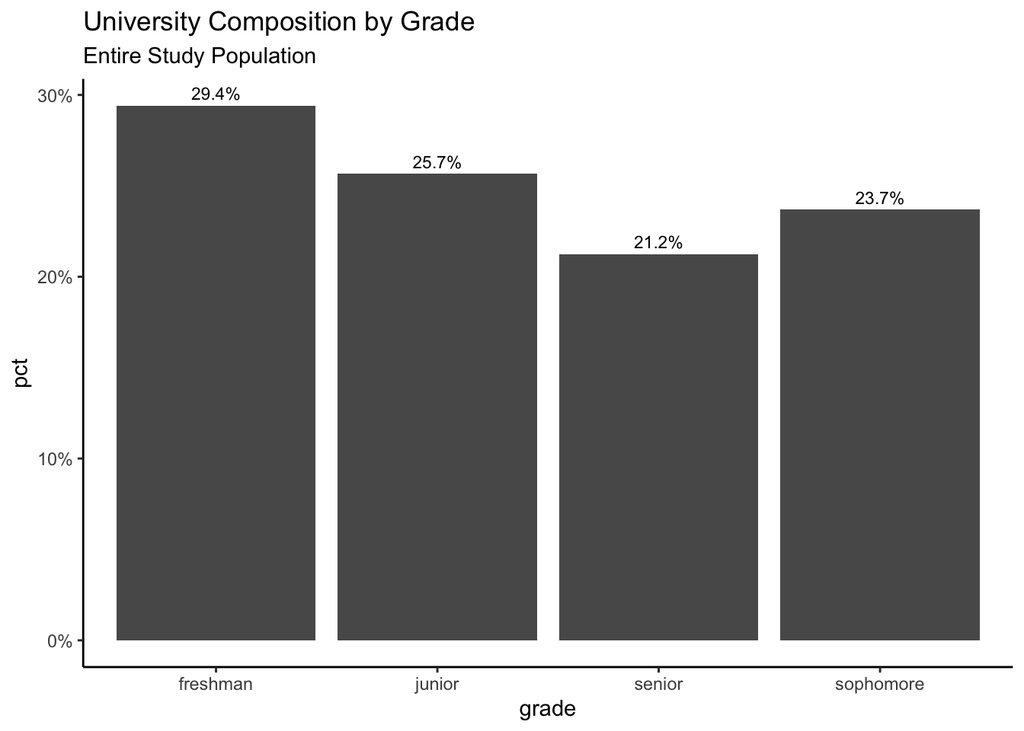

## Question 4: Sampling

Usually in the real world, our populations are too big or difficult to measure, so we take a sample to try and gauge the relative proportion of each group. Using `rep_sample_n` from the `infer` package, draw 5000 samples of 25 students each from the population from question 3. Use `set.seed(02139)` so that your randomly drawn distributions have the same values as ours. Save the percent freshmen in each sample. Plot the distribution of percent freshmen in a nice plot.

## Question 5: Sampling and Sample Size

Now, create a plot that shows what happens to the variation in the distribution when we increase our sample size.

- First, create a *list* of four different sizes (25,50,100,500). Use `sizes <- set_names(sizes, names = sizes)`, to make sizes a “named” list, which will help R cycle through your code.
- Reset the seed to 02139. Use map_df to call `rep_sample_n` to sample from your university tibble, using size as an input. Your output should be a tibble with 3,375,000 rows and four columns; one for the draw number (1:5000), one for the size (25,50,100, or 500), the student’s ID, and their grade. If you’re stuck on how to cycle through the elements of the “sizes” list, try using `size =.` in your `map_df()` expression, and then telling R what the `.id` stands for outside the parentheses. You don’t need to print this tibble
- Use a summarize function to count the number of freshmen in each sample, and then take the proportion. Your tibble should now have 20,000 rows; one for each draw.
- Using `geom_density`, plot the distribution of the proportion of freshmen by sample size. Your plot should look roughly like this:

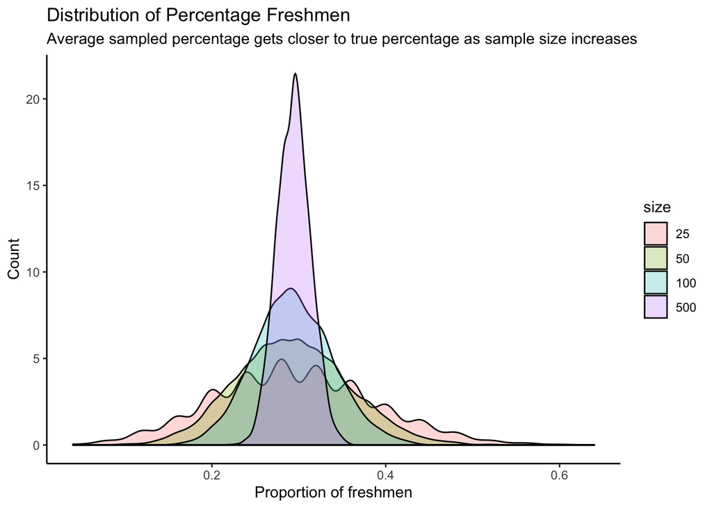

## Question 6: Publish Your Plot

Publish your plot (and just your plot) to Rpubs. To do this, create a separate RMD, called ps_5_rpub.Rmd. Include only the code necessary for creating this plot. Click “publish” and copy the link. Within that rmd, you should also call ggsave() to save the plot within a new folder in this repo called “graphics”. Save the plot as “dist_by_sample_size.png”. Commit and push the rmd, plot, and html (but not the rsconnect) to github.

For this question, print both the link to the rpubs plot, and a call to print the plot you saved here. `knitr::include_graphics` should help here.

## Question 7: Reprex

Make a simple reproducible example, and post it as an Issue on your GitHub repo for this problem set. You can see an example from Preceptor [here](https://github.com/ddsjoberg/gtsummary/issues/391). [Tidyverse’s help page](https://www.tidyverse.org/help/) also has some helpful tips on how to do this.

- Find a simple piece of example data. Either define a slice of your real data using dput(), assign a simple toy tibble within your code, or use one of R’s built in datasets like iris or mtcars
- Load all the packages that you need to run your code
- Generate some kind of silly error. You can call mean on a character vector, or try to plot data that’s not in a tibble.
- Put this code into a temp.R file. (You need to do this work somewhere.) Highlight and copy the code. Then run `reprex()`. You’ll need to load the reprex package for this to work. You don’t need to commit or push your temp file.
- `reprex()` will automatically copy your reprex to the clipboard. Paste it as a GitHub issue in your repo.
- Print the URL to your github issue here.

## Question 8: Demonstrating Understanding of Sampling

Imagine that you are running for president in a large, diverse country, and elections are next week. In your country, the candidate who wins the popular vote (gets the most votes) wins the presidency. Your country has 10 states and five major cities. Your party has never been elected before.

The head of your campaign offers you two options for how to spend the last of your polling budget. You can run polls of 1,000 randomly sampled people in each of the five major cities, or you can sample 500 people in every state. Tell us which option you prefer, and why. **There is no right answer here – you can be creative.** If you need more facts to justify your decision, go ahead and make them up. But your answer should include the nine core concepts from [Section 9.3.1](https://davidkane9.github.io/PPBDS/9-sampling.html#sampling-framework) in PPBDS. If you’re feeling stuck, you can read [this article](https://qz.com/714976/why-theres-no-exit-poll-after-the-brexit-vote/) about Brexit’s polling or [this article](https://www.vox.com/mischiefs-of-faction/2018/10/26/18029494/why-did-brazilian-pollsters-go-wrong) about Brazil’s polling for inspiration.